# Séance 2: Exemples de visualisation en assurance

# Objectif

La première séance a pour but de se familiarer avec les différents graphiques réalisables avec R. Cette deuxième séance est divisée en deux parties:

- mieux communiquer les informations sur les données en assurance
- mieux comprendre certaines notions techniques actuarielles

Dans la continuité de la première séance, il s’agit d’utiliser les graphiques de base pour mieux représenter les données.

# Données

## Données R

**Séries de données dans certains packages R**

```r
library(MASS)
head(Insurance)
```

```
##   District  Group   Age Holders Claims
## 1        1    <1l   <25     197     38
## 2        1    <1l 25-29     264     35
## 3        1    <1l 30-35     246     20
## 4        1    <1l   >35    1680    156
## 5        1 1-1.5l   <25     284     63
## 6        1 1-1.5l 25-29     536     84
```

```r
head(Boston)
```

```
##      crim zn indus chas   nox    rm  age    dis rad tax ptratio  black
## 1 0.00632 18  2.31    0 0.538 6.575 65.2 4.0900   1 296    15.3 396.90
## 2 0.02731  0  7.07    0 0.469 6.421 78.9 4.9671   2 242    17.8 396.90
## 3 0.02729  0  7.07    0 0.469 7.185 61.1 4.9671   2 242    17.8 392.83
## 4 0.03237  0  2.18    0 0.458 6.998 45.8 6.0622   3 222    18.7 394.63
## 5 0.06905  0  2.18    0 0.458 7.147 54.2 6.0622   3 222    18.7 396.90
## 6 0.02985  0  2.18    0 0.458 6.430 58.7 6.0622   3 222    18.7 394.12
##   lstat medv
## 1  4.98 24.0
## 2  9.14 21.6
## 3  4.03 34.7
## 4  2.94 33.4
## 5  5.33 36.2
## 6  5.21 28.7
```

```r
library(Ecdat)
head(HI)
```

```
##   whrswk hhi whi hhi2  education  race hispanic experience kidslt6 kids618
## 1      0  no  no   no 13-15years white       no       13.0       2       1
## 2     50  no yes   no 13-15years white       no       24.0       0       1
## 3     40 yes  no  yes    12years white       no       43.0       0       0
## 4     40  no yes  yes 13-15years white       no       17.0       0       1
## 5      0 yes  no  yes  9-11years white       no       44.5       0       0
## 6     40 yes yes  yes    12years white       no       32.0       0       0
##    husby       region   wght
## 1 11.960 northcentral 214986
## 2  1.200 northcentral 210119
## 3 31.275 northcentral 219955
## 4  9.000 northcentral 210317
## 5  0.000 northcentral 219955
## 6 15.690 northcentral 208148
```

```r
head(Mofa)
```

```
##         capexp    gdp sales  nbaf netinc
## Belgium   2.00 0.8524  2.12  4.82   11.5
## Denmark   3.00 0.5700  0.15  1.24    0.1
## France    3.00 5.3726  2.70  9.08    0.4
## Germany  24.00 6.6299  5.35 10.85    9.1
## Greece    0.25 0.3395  0.02  0.79    0.1
## Ireland   1.00 0.1718  0.29  2.15    5.1
```

```r
library(evir)
data(danish)
head(danish)
```

```
## [1] 1.683748 2.093704 1.732581 1.779754 4.612006 8.725274
```

```r
# str(danish)
# typeof(danish)
# plot(danish)
```

## Open Data

Les données sont sur les leurs sites

- [Données météorologiques](http://eca.knmi.nl/dailydata/index.php)
- [Données sur les sinistres automobiles corporels](https://www.data.gouv.fr/fr/datasets/base-de-donnees-accidents-corporels-de-la-circulation/)

Pour ceux qui du temps restant :

- [Correspondance code postal insee 2013 avec altitude, superficie, population et gécodage](http://public.opendatasoft.com/explore/dataset/correspondance-code-insee-code-postal/)
- [Carte des Codes Postaux 2016](http://datanova.legroupe.laposte.fr/explore/dataset/carte-des-codes-postaux/table/): données de la Poste, centroïdes des codes postaux
- [Catégories socio-professionnelles](http://public.opendatasoft.com/explore/dataset/evolution-et-structure-de-la-population-france-2012-categories-socio-professionn/information/)
- [Migrations résidentielles](http://public.opendatasoft.com/explore/dataset/evolution-et-structure-de-la-population-france-2012-migrations-residentielles/information/)
- [Résumés statistiques des communes, départements et régions](http://public.opendatasoft.com/explore/dataset/resume-statistique-communes-departements-et-regions-france-2012-2013-2014/)
- [Capacités des communes en hébergement touristique](http://public.opendatasoft.com/explore/dataset/capacite-des-communes-en-hebergement-touristique-2015/)
- [Revenus imposables et montants des impôts](http://public.opendatasoft.com/explore/dataset/revenus-imposables-et-montant-des-impots-1998-2005/)
- [Equipement sports et loisir par commune](http://public.opendatasoft.com/explore/dataset/equip-sport-loisir-socio-infra-2014/)
- [Décès par commune, départements et régions](http://public.opendatasoft.com/explore/dataset/deces-par-commune-departement-et-region-de-2003-a-2013/)

## Données pricing game

L’Institut des Actuaires a organisé deux pricing games, et les données peuvent être utilisées:

- Pricing game 2015
- Pricing game 2016

# Types de graphiques

A part les graphiques basiques vus à la première séance, on peut utiliser d’autres graphiques plus avancés.

## Treemap

```
##   District  Group   Age Holders Claims
## 1        1    <1l   <25     197     38
## 2        1    <1l 25-29     264     35
## 3        1    <1l 30-35     246     20
## 4        1    <1l   >35    1680    156
## 5        1 1-1.5l   <25     284     63
## 6        1 1-1.5l 25-29     536     84
```

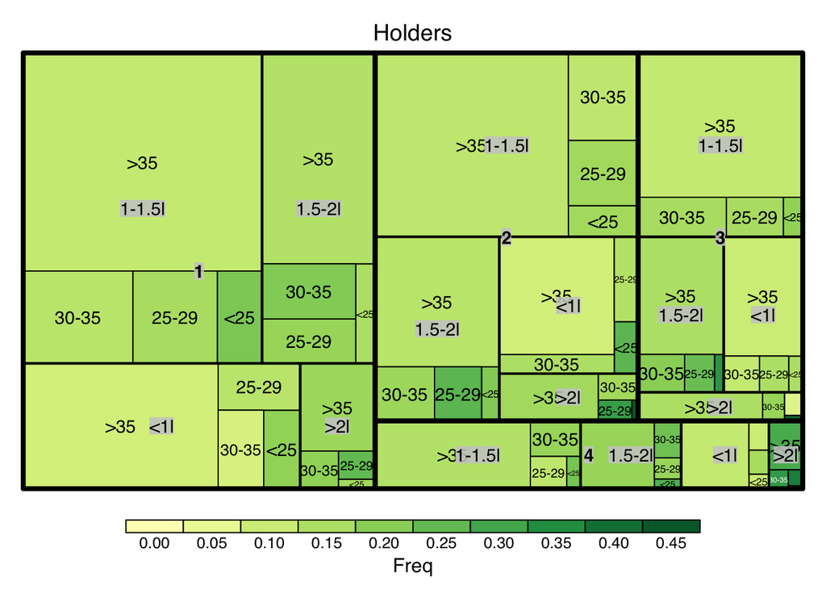

## Sunbrust

[interactive chart not shown]

## Quelques suggestions de graphiques

Pour les données météorologiques, on peut choisir une ville donnée

- Evolution des températures (pression, quantité de pluie, etc) avec dygraphs
- Corrélation des différentes grandeurs
- Tendance et saisonnalité

Pour les données sur les accidents

- Analyse des lieux d’accidents
- Analyse des parties accidentées
- Evolution temporelles de certaines caractéristiques

Dans les deux cas, la situation géographique est très importante. Pour vous préparer la prochaine séance, vous pouvez lire la documentation sur [leafet pour R](https://rstudio.github.io/leaflet/).

Pour les données concernant la population, on peut utiliser les [pyramides](http://walkerke.github.io/2014/06/rcharts-pyramids/)

# Paramètres graphiques

Vous devez également prêter attention aux différents éléments suivants:

- Titre principal
- Titres des axes x et y
- Couleurs, formes des symboles
- Couleur de l’arrière-plan
- Polices des caractères
- Légende (position et textes)

# Interactivité

## plotly

Les packages pour des graphiques interactifs: plotly (de plus en plus développé), rCharts, highcharter, googleVis

Le package plotly permet de convertier un graphique créé avec ggplot2 (la plupart d’entre eux) en un graphique interactif grâce à la fonction `ggplotly`.

```r
head(Insurance)
```

```
##   District  Group   Age Holders Claims
## 1        1    <1l   <25     197     38
## 2        1    <1l 25-29     264     35
## 3        1    <1l 30-35     246     20
## 4        1    <1l   >35    1680    156
## 5        1 1-1.5l   <25     284     63
## 6        1 1-1.5l 25-29     536     84
```

```r
p=ggplot(data=Insurance,aes(Age,Holders,color=District))+geom_jitter()
ggplotly(p)
```

[interactive chart not shown]

## dygraphs

[interactive chart not shown]

Copyright © 2016 DatavISUP